# Transitioning To R: Tutorial Notes (Plus R Viz)

#### Other quick overviews, cleaning, and organization of data

```r
library(palmerpenguins)
```

```r
library(skimr)
skim_without_charts(penguins)
```

Data summary

| Name | penguins |
| --- | --- |
| Number of rows | 344 |
| Number of columns | 8 |
| _______________________ |  |
| Column type frequency: |  |
| factor | 3 |
| numeric | 5 |
| ________________________ |  |
| Group variables | None |

**Variable type: factor**

| skim_variable | n_missing | complete_rate | ordered | n_unique | top_counts |
| --- | --- | --- | --- | --- | --- |
| species | 0 | 1.00 | FALSE | 3 | Ade: 152, Gen: 124, Chi: 68 |
| island | 0 | 1.00 | FALSE | 3 | Bis: 168, Dre: 124, Tor: 52 |
| sex | 11 | 0.97 | FALSE | 2 | mal: 168, fem: 165 |

**Variable type: numeric**

| skim_variable | n_missing | complete_rate | mean | sd | p0 | p25 | p50 | p75 | p100 |
| --- | --- | --- | --- | --- | --- | --- | --- | --- | --- |
| bill_length_mm | 2 | 0.99 | 43.92 | 5.46 | 32.1 | 39.23 | 44.45 | 48.5 | 59.6 |
| bill_depth_mm | 2 | 0.99 | 17.15 | 1.97 | 13.1 | 15.60 | 17.30 | 18.7 | 21.5 |
| flipper_length_mm | 2 | 0.99 | 200.92 | 14.06 | 172.0 | 190.00 | 197.00 | 213.0 | 231.0 |
| body_mass_g | 2 | 0.99 | 4201.75 | 801.95 | 2700.0 | 3550.00 | 4050.00 | 4750.0 | 6300.0 |
| year | 0 | 1.00 | 2008.03 | 0.82 | 2007.0 | 2007.00 | 2008.00 | 2009.0 | 2009.0 |

```r
glimpse(penguins)
```

```
## Rows: 344
## Columns: 8
## $ species           <fct> Adelie, Adelie, Adelie, Adelie, Adelie, Adelie, Adel…
## $ island            <fct> Torgersen, Torgersen, Torgersen, Torgersen, Torgerse…
## $ bill_length_mm    <dbl> 39.1, 39.5, 40.3, NA, 36.7, 39.3, 38.9, 39.2, 34.1, …
## $ bill_depth_mm     <dbl> 18.7, 17.4, 18.0, NA, 19.3, 20.6, 17.8, 19.6, 18.1, …
## $ flipper_length_mm <int> 181, 186, 195, NA, 193, 190, 181, 195, 193, 190, 186…
## $ body_mass_g       <int> 3750, 3800, 3250, NA, 3450, 3650, 3625, 4675, 3475, …
## $ sex               <fct> male, female, female, NA, female, male, female, male…
## $ year              <int> 2007, 2007, 2007, 2007, 2007, 2007, 2007, 2007, 2007…
```

```r
str(penguins) # 'str' here stands for structure, not string!!
```

```
## tibble [344 × 8] (S3: tbl_df/tbl/data.frame)
##  $ species          : Factor w/ 3 levels "Adelie","Chinstrap",..: 1 1 1 1 1 1 1 1 1 1 ...
##  $ island           : Factor w/ 3 levels "Biscoe","Dream",..: 3 3 3 3 3 3 3 3 3 3 ...
##  $ bill_length_mm   : num [1:344] 39.1 39.5 40.3 NA 36.7 39.3 38.9 39.2 34.1 42 ...
##  $ bill_depth_mm    : num [1:344] 18.7 17.4 18 NA 19.3 20.6 17.8 19.6 18.1 20.2 ...
##  $ flipper_length_mm: int [1:344] 181 186 195 NA 193 190 181 195 193 190 ...
##  $ body_mass_g      : int [1:344] 3750 3800 3250 NA 3450 3650 3625 4675 3475 4250 ...
##  $ sex              : Factor w/ 2 levels "female","male": 2 1 1 NA 1 2 1 2 NA NA ...
##  $ year             : int [1:344] 2007 2007 2007 2007 2007 2007 2007 2007 2007 2007 ...
```

```r
# Using pipe
penguins %>%
  select(species, island) %>%
  rename(iSLaNd_NeW=island)
```

```
## # A tibble: 344 × 2
##    species iSLaNd_NeW
##    <fct>   <fct>
##  1 Adelie  Torgersen
##  2 Adelie  Torgersen
##  3 Adelie  Torgersen
##  4 Adelie  Torgersen
##  5 Adelie  Torgersen
##  6 Adelie  Torgersen
##  7 Adelie  Torgersen
##  8 Adelie  Torgersen
##  9 Adelie  Torgersen
## 10 Adelie  Torgersen
## # ℹ 334 more rows
```

```r
# rename_with() similarly renames columns, but allows a function to be applied the the column names:
rename_with(penguins, tolower)
```

```
## # A tibble: 344 × 8
##    species island    bill_length_mm bill_depth_mm flipper_length_mm body_mass_g
##    <fct>   <fct>              <dbl>         <dbl>             <int>       <int>
##  1 Adelie  Torgersen           39.1          18.7               181        3750
##  2 Adelie  Torgersen           39.5          17.4               186        3800
##  3 Adelie  Torgersen           40.3          18                 195        3250
##  4 Adelie  Torgersen           NA            NA                  NA          NA
##  5 Adelie  Torgersen           36.7          19.3               193        3450
##  6 Adelie  Torgersen           39.3          20.6               190        3650
##  7 Adelie  Torgersen           38.9          17.8               181        3625
##  8 Adelie  Torgersen           39.2          19.6               195        4675
##  9 Adelie  Torgersen           34.1          18.1               193        3475
## 10 Adelie  Torgersen           42            20.2               190        4250
## # ℹ 334 more rows
## # ℹ 2 more variables: sex <fct>, year <int>
```

```r
adelie_penguins <- penguins %>% filter(species == "Adelie")
adelie_penguins
```

```
## # A tibble: 152 × 8
##    species island    bill_length_mm bill_depth_mm flipper_length_mm body_mass_g
##    <fct>   <fct>              <dbl>         <dbl>             <int>       <int>
##  1 Adelie  Torgersen           39.1          18.7               181        3750
##  2 Adelie  Torgersen           39.5          17.4               186        3800
##  3 Adelie  Torgersen           40.3          18                 195        3250
##  4 Adelie  Torgersen           NA            NA                  NA          NA
##  5 Adelie  Torgersen           36.7          19.3               193        3450
##  6 Adelie  Torgersen           39.3          20.6               190        3650
##  7 Adelie  Torgersen           38.9          17.8               181        3625
##  8 Adelie  Torgersen           39.2          19.6               195        4675
##  9 Adelie  Torgersen           34.1          18.1               193        3475
## 10 Adelie  Torgersen           42            20.2               190        4250
## # ℹ 142 more rows
## # ℹ 2 more variables: sex <fct>, year <int>
```

```r
library(janitor)
# Keeps column names consistent
clean_names(penguins)
```

```
## # A tibble: 344 × 8
##    species island    bill_length_mm bill_depth_mm flipper_length_mm body_mass_g
##    <fct>   <fct>              <dbl>         <dbl>             <int>       <int>
##  1 Adelie  Torgersen           39.1          18.7               181        3750
##  2 Adelie  Torgersen           39.5          17.4               186        3800
##  3 Adelie  Torgersen           40.3          18                 195        3250
##  4 Adelie  Torgersen           NA            NA                  NA          NA
##  5 Adelie  Torgersen           36.7          19.3               193        3450
##  6 Adelie  Torgersen           39.3          20.6               190        3650
##  7 Adelie  Torgersen           38.9          17.8               181        3625
##  8 Adelie  Torgersen           39.2          19.6               195        4675
##  9 Adelie  Torgersen           34.1          18.1               193        3475
## 10 Adelie  Torgersen           42            20.2               190        4250
## # ℹ 334 more rows
## # ℹ 2 more variables: sex <fct>, year <int>
```

```r
# By adding a minus sign, it also sorts in desc order. Then we can save the new table in another df
penguins2 <- penguins %>% arrange(-bill_length_mm)
# Aggregating data, and use summarize() according to groups: summarize each group down to one row, with additional columns for each of the specified summary statistics (in this case, the mean and maximum of bill length.)
penguins %>% group_by(island, species) %>% drop_na() %>% summarize(mean_bill_len = mean(bill_length_mm), max_bill_len = max(bill_length_mm))
```

```
## # A tibble: 5 × 4
## # Groups:   island [3]
##   island    species   mean_bill_len max_bill_len
##   <fct>     <fct>             <dbl>        <dbl>
## 1 Biscoe    Adelie             39.0         45.6
## 2 Biscoe    Gentoo             47.6         59.6
## 3 Dream     Adelie             38.5         44.1
## 4 Dream     Chinstrap          48.8         58
## 5 Torgersen Adelie             39.0         46
```

```r
penguins %>% mutate(body_mass_kg = body_mass_g/1000, flipper_length_m = flipper_length_mm/1000)
```

```
## # A tibble: 344 × 10
##    species island    bill_length_mm bill_depth_mm flipper_length_mm body_mass_g
##    <fct>   <fct>              <dbl>         <dbl>             <int>       <int>
##  1 Adelie  Torgersen           39.1          18.7               181        3750
##  2 Adelie  Torgersen           39.5          17.4               186        3800
##  3 Adelie  Torgersen           40.3          18                 195        3250
##  4 Adelie  Torgersen           NA            NA                  NA          NA
##  5 Adelie  Torgersen           36.7          19.3               193        3450
##  6 Adelie  Torgersen           39.3          20.6               190        3650
##  7 Adelie  Torgersen           38.9          17.8               181        3625
##  8 Adelie  Torgersen           39.2          19.6               195        4675
##  9 Adelie  Torgersen           34.1          18.1               193        3475
## 10 Adelie  Torgersen           42            20.2               190        4250
## # ℹ 334 more rows
## # ℹ 4 more variables: sex <fct>, year <int>, body_mass_kg <dbl>,
## #   flipper_length_m <dbl>
```

```r
# Separating columns and uniting them (just testing the function,,, i know splitting 'species' doesn't make sense at all QvQ)
adelie_penguins <- separate(adelie_penguins, species, into=c("sp","ecies"), sep='l') # 'l' gets eaten (but don't worry- we'll get it back right after unite() via the same separator)
adelie_penguins
```

```
## # A tibble: 152 × 9
##    sp    ecies island bill_length_mm bill_depth_mm flipper_length_mm body_mass_g
##    <chr> <chr> <fct>           <dbl>         <dbl>             <int>       <int>
##  1 Ade   ie    Torge…           39.1          18.7               181        3750
##  2 Ade   ie    Torge…           39.5          17.4               186        3800
##  3 Ade   ie    Torge…           40.3          18                 195        3250
##  4 Ade   ie    Torge…           NA            NA                  NA          NA
##  5 Ade   ie    Torge…           36.7          19.3               193        3450
##  6 Ade   ie    Torge…           39.3          20.6               190        3650
##  7 Ade   ie    Torge…           38.9          17.8               181        3625
##  8 Ade   ie    Torge…           39.2          19.6               195        4675
##  9 Ade   ie    Torge…           34.1          18.1               193        3475
## 10 Ade   ie    Torge…           42            20.2               190        4250
## # ℹ 142 more rows
## # ℹ 2 more variables: sex <fct>, year <int>
```

```r
# unite() is just in the reverse order
unite(adelie_penguins, 'species', sp, ecies, sep='l')
```

```
## # A tibble: 152 × 8
##    species island    bill_length_mm bill_depth_mm flipper_length_mm body_mass_g
##    <chr>   <fct>              <dbl>         <dbl>             <int>       <int>
##  1 Adelie  Torgersen           39.1          18.7               181        3750
##  2 Adelie  Torgersen           39.5          17.4               186        3800
##  3 Adelie  Torgersen           40.3          18                 195        3250
##  4 Adelie  Torgersen           NA            NA                  NA          NA
##  5 Adelie  Torgersen           36.7          19.3               193        3450
##  6 Adelie  Torgersen           39.3          20.6               190        3650
##  7 Adelie  Torgersen           38.9          17.8               181        3625
##  8 Adelie  Torgersen           39.2          19.6               195        4675
##  9 Adelie  Torgersen           34.1          18.1               193        3475
## 10 Adelie  Torgersen           42            20.2               190        4250
## # ℹ 142 more rows
## # ℹ 2 more variables: sex <fct>, year <int>
```

### Visualization in R

Anscombe’s quartet: four datasets (‘sets’) that have nearly identical summary statistics. But just looking at the summary statistics and concluding that these four datasets are the same can be very misleading. -> we now visualize the data

```r
library(Tmisc)

data(quartet)
head(quartet)
```

```
##   set  x    y
## 1   I 10 8.04
## 2   I  8 6.95
## 3   I 13 7.58
## 4   I  9 8.81
## 5   I 11 8.33
## 6   I 14 9.96
```

```r
summary(quartet) # Four data'set's: the quartet. So we group them and see the summary statistics
```

```
##   set           x            y
##  I  :11   Min.   : 4   Min.   : 3.100
##  II :11   1st Qu.: 7   1st Qu.: 6.117
##  III:11   Median : 8   Median : 7.520
##  IV :11   Mean   : 9   Mean   : 7.501
##           3rd Qu.:11   3rd Qu.: 8.748
##           Max.   :19   Max.   :12.740
```

```r
quartet %>% group_by(set) %>% summarize(mean(x),sd(x),mean(y),sd(y),cor(x,y)) # Identical summary statistics
```

```
## # A tibble: 4 × 6
##   set   `mean(x)` `sd(x)` `mean(y)` `sd(y)` `cor(x, y)`
##   <fct>     <dbl>   <dbl>     <dbl>   <dbl>       <dbl>
## 1 I             9    3.32      7.50    2.03       0.816
## 2 II            9    3.32      7.50    2.03       0.816
## 3 III           9    3.32      7.5     2.03       0.816
## 4 IV            9    3.32      7.50    2.03       0.817
```

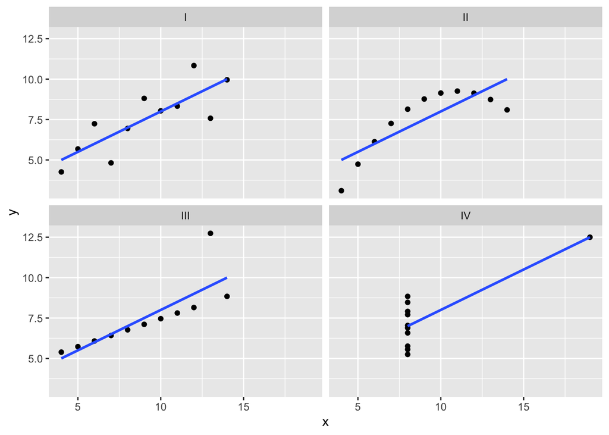

```r
ggplot(quartet,aes(x,y)) + geom_point() + geom_smooth(method=lm,se=FALSE) + facet_wrap(~set) # Apparently they aren't identical.
```

#### ggplot2

‘gg’ stands for ‘grammar of graphics’.

**Core concepts**:

- Geoms: the geometric object used to represent the data.
- Aesthetics: visual properties of the variables we have chosen from our data in the ‘geoms’ step (eg. x, y, color, shape, size, alpha).
- Facets: let you display smaller groups, or subsets, of ur data.
- Labels and annotations

#### Basic grammar for plotting in ggplot2

1. Every ggplot2 plot starts with the ggplot(data) function, by running this single function we create an empty plot.
2. We use the **plus sign** `+` to add **layers** (by choosing a *geom* (`geom_function()`) to represent our data) to our plot. Plots are built through combinations of layers.
3. `mapping=aes` specifies what *aesthetics* to use for the plot. It defines the **mapping between ur data and ur plot**. Mapping means matching up a specific variable in the dataset with a specific aesthetic in the plot. *We choose what variables from our dataset to use*, they can be mapped to the axes (like in our example) and to the color, size, shape, etc.
- (Note that in the example above for the ‘quartet’ dataset, `aes(x, y)` is set in `ggplot()`, and it becomes the default mapping for all subsequent layers (i.e., geom_point(), geom_smooth()). Use local aes() in a specific geom if that layer needs unique mappings (eg. specific colors). This avoids repetition and ensures consistency across layers.)

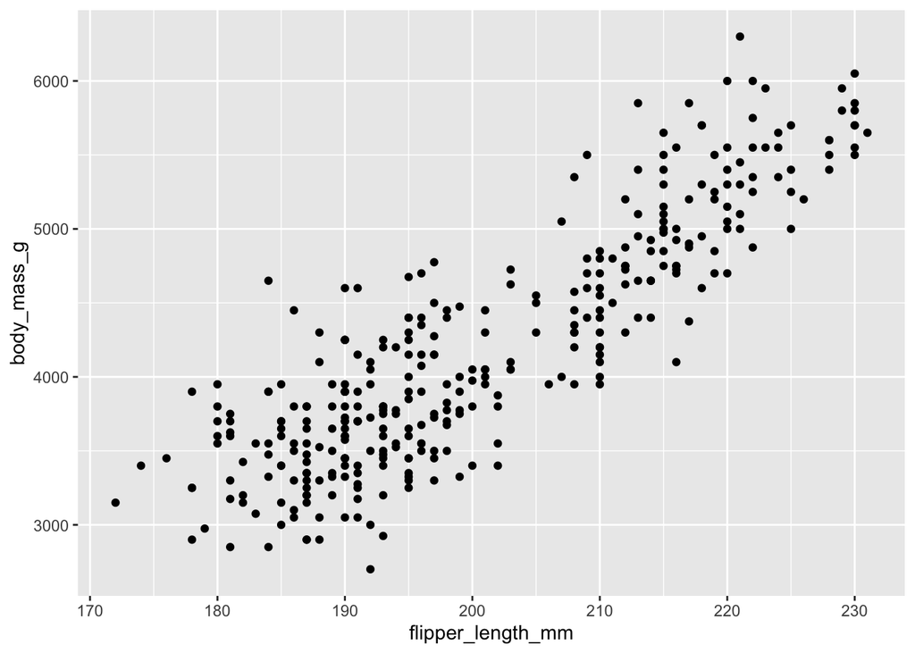

```r
# Using the penguins dataset

ggplot(penguins) +
  geom_point(mapping=aes(x=flipper_length_mm,y=body_mass_g)) # Using a scatter plot (geom_point) to plot the relationship between flipper length and body mass.
```

#### More about aesthetics

Rn we can’t tell which data points represent which species of penguins. To solve this we can map a new variable (species) to a new aesthetic, here we’ve chosen color: `color=species` (changing the visual property ‘color’ to ‘shape’, ‘size’ or transparency ‘alpha’ would also work). It even automatically gives a legend. Awwww

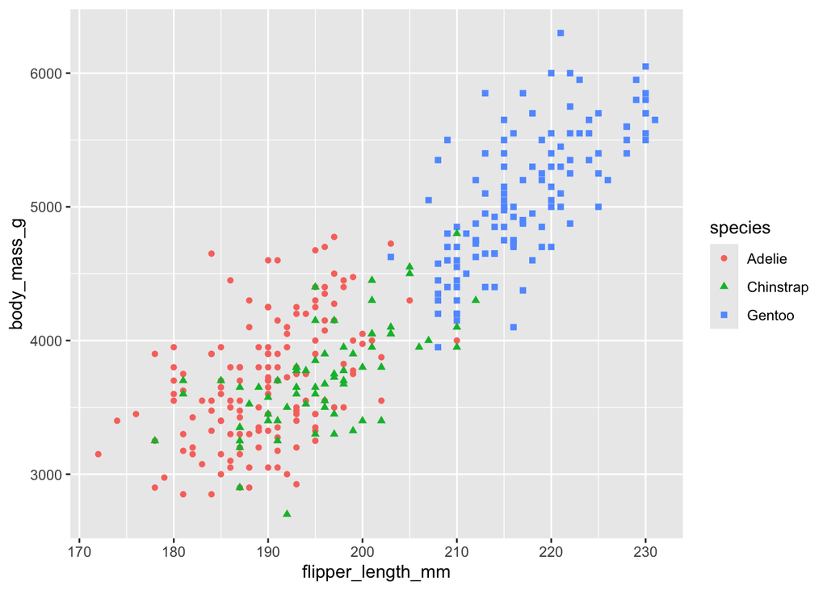

```r
ggplot(penguins) +
  geom_point(mapping=aes(x=flipper_length_mm,y=body_mass_g,color=species,shape=species))
```

If we don’t want to map a variable to the color property but just aim to change the color overall, move the `color=` argument **outside** the `mapping=aes()` function as a separate argument of the `geom_function()`.

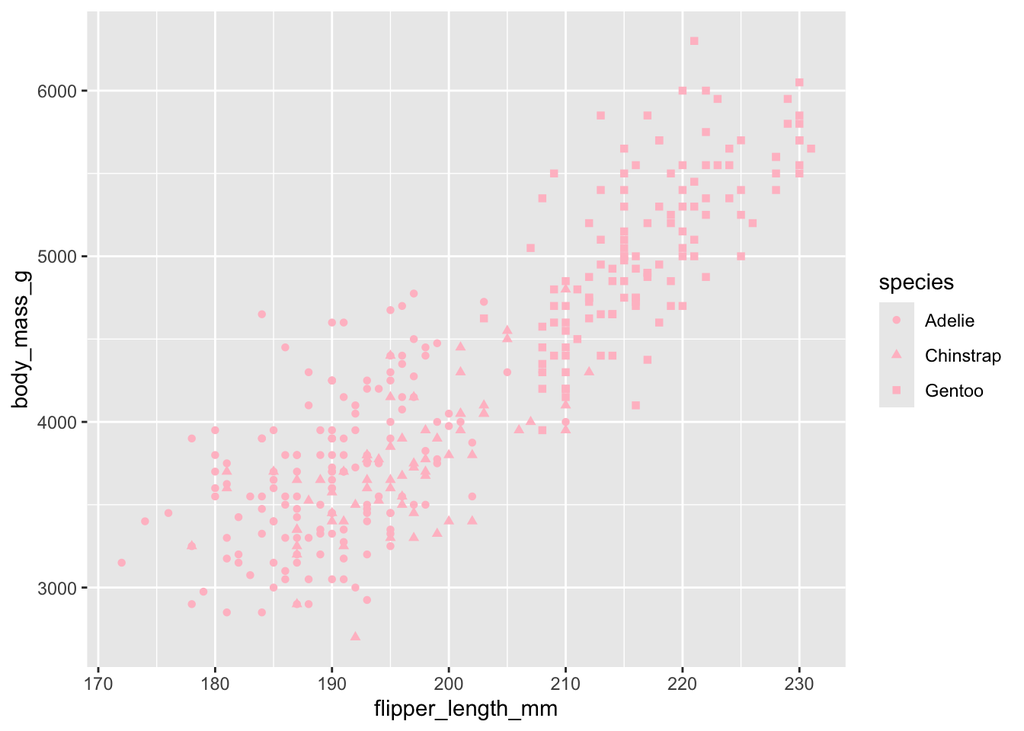

```r
ggplot(penguins) +
  geom_point(mapping=aes(x=flipper_length_mm,y=body_mass_g,shape=species),color="pink")
```

#### More about geom functions

We add another layer this time.

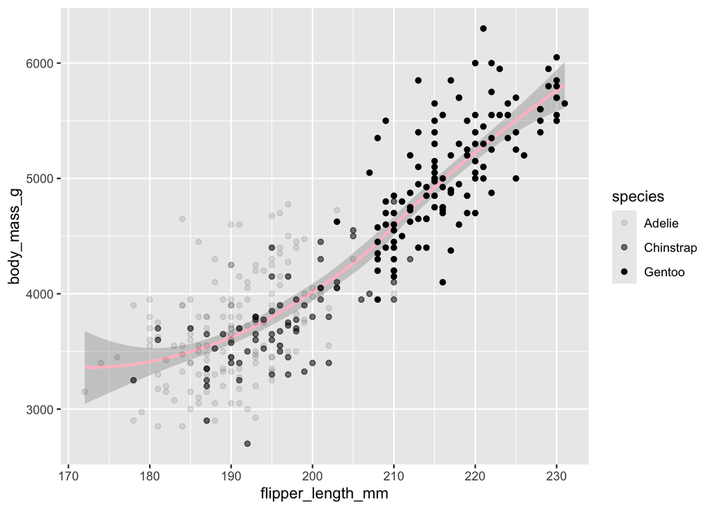

```r
ggplot(penguins) +
  geom_smooth(mapping=aes(x=flipper_length_mm,y=body_mass_g),color="pink") +
  geom_point(mapping=aes(x=flipper_length_mm,y=body_mass_g,alpha=species))
```

We want to draw a separate smooth line for each species.

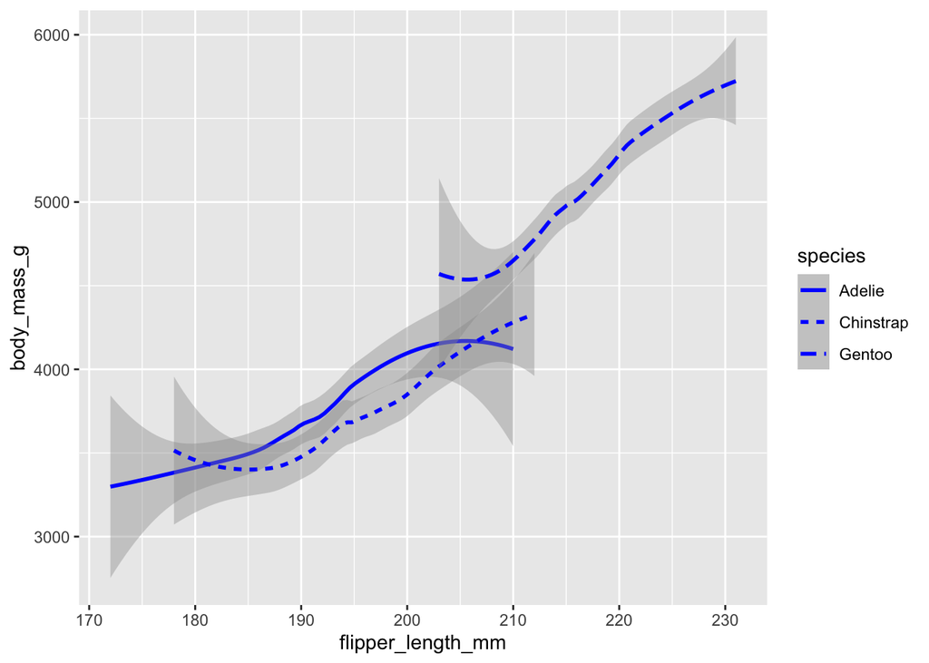

```r
ggplot(penguins) +
  geom_smooth(mapping=aes(x=flipper_length_mm,y=body_mass_g,linetype=species),color="blue")
```

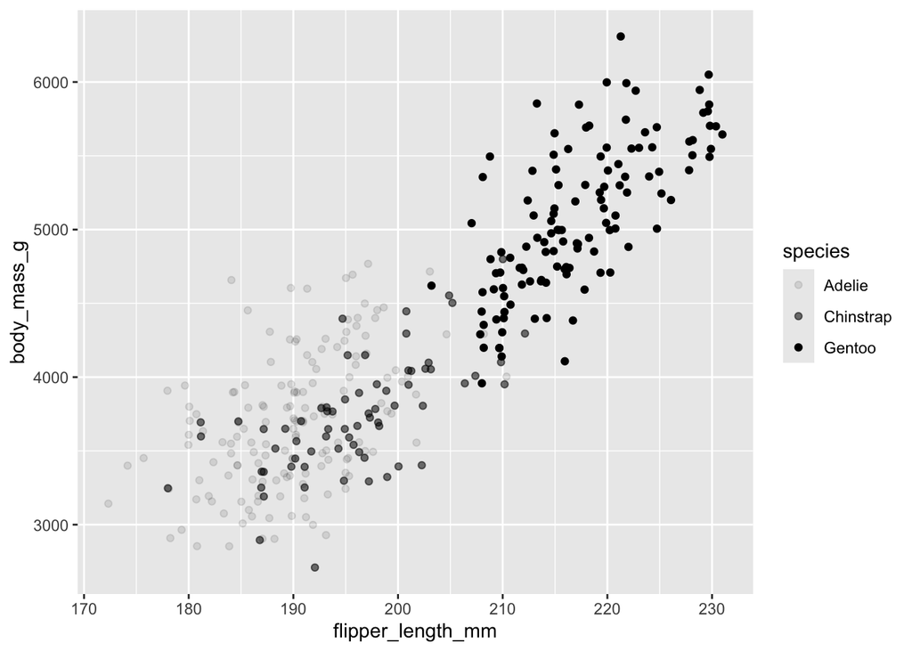

```r
ggplot(penguins) +
  geom_jitter(mapping=aes(x=flipper_length_mm,y=body_mass_g,alpha=species))
```

Now we explore bar charts using the ‘diamonds’ dataset. Note that we did not map a variable to the y-axis, since when we use `geom_bar` **R automatically counts how many times each x-value appears in the data**. Here, ‘cut’ is a variable containing *ordered factors* with 5 levels.

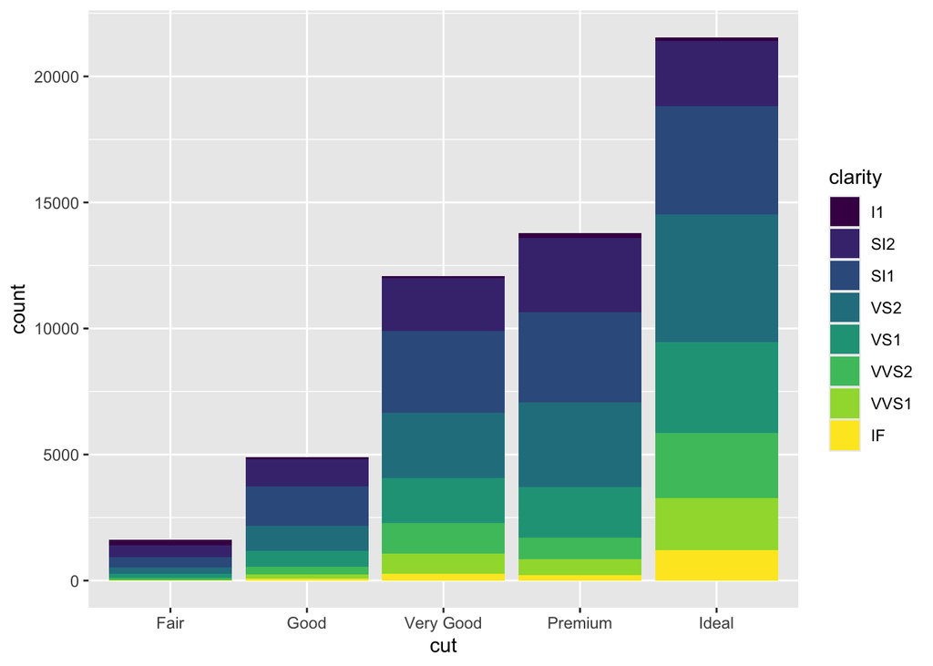

```r
ggplot(diamonds) +
  geom_bar(mapping=aes(x=cut, fill=clarity)) # When we map a *new variable* to 'fill', it will display a stacked bar chart.
```

#### Facets, labels and annotations

**Facets**: displays subsets. Two functions:

- `facet_wrap` lets us create a separate plot for a single variable.

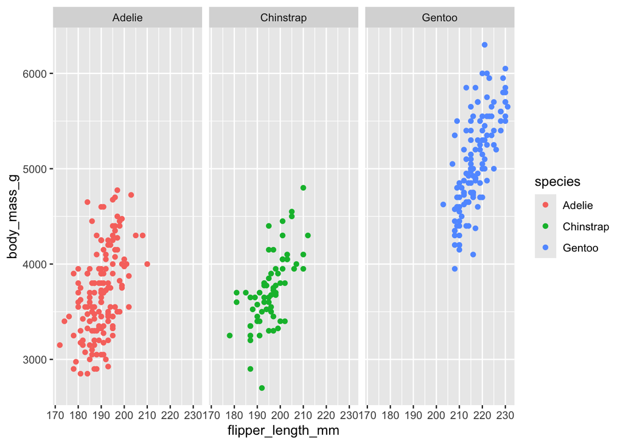

```r
ggplot(penguins) +
  geom_point(mapping=aes(x=flipper_length_mm,y=body_mass_g,color=species)) +
  facet_wrap(~species)
```

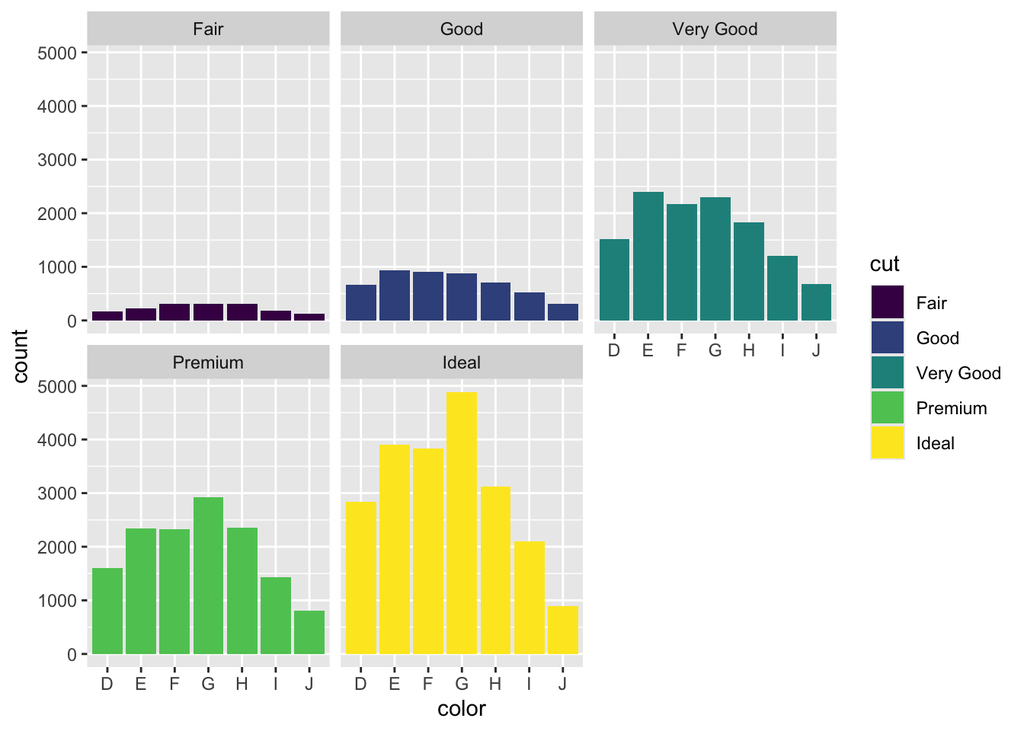

```r
ggplot(diamonds) +
  geom_bar(mapping=aes(x=color, fill=cut)) +
  facet_wrap(~cut)
```

The **tilde `~` symbol** appears all the time. In R, it’s used as a *formula* syntax to define a relationship between **variables** (eg. y~x). See below for two variables!

- `facet_grid()` allows us to facet the plot with **two variables**. It splits the plot into facets vertically by values of the first variable and horizontally by values of the second variable (since it’s `y~x`)

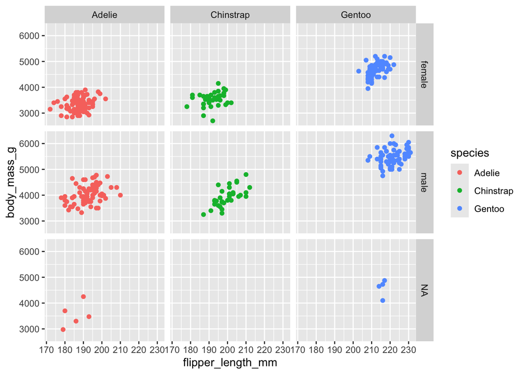

```r
ggplot(penguins) +
  geom_point(mapping=aes(x=flipper_length_mm,y=body_mass_g,color=species)) +
  facet_grid(sex~species)
```

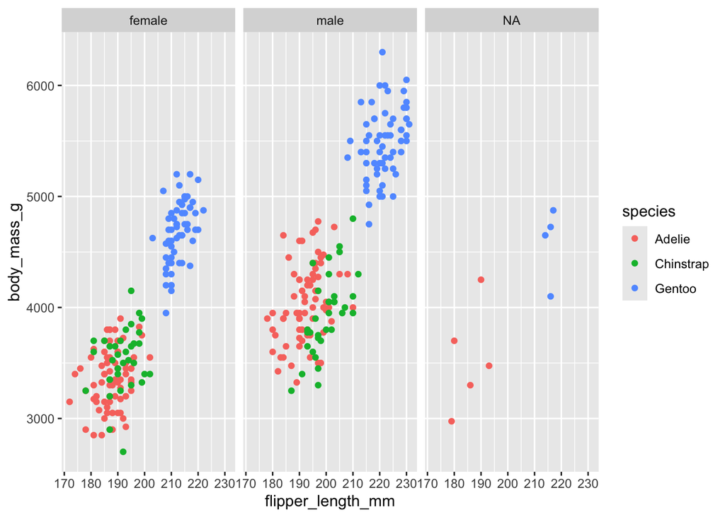

```r
# Also applicable for a single variable as well
ggplot(penguins) +
  geom_point(mapping=aes(x=flipper_length_mm,y=body_mass_g,color=species)) +
  facet_grid(~sex)
```

**Labels**: titles, subtitles, captions; placed **outside** of the grid.

`+ labs(title="",subtitle="",caption="")`

**Annotations**: place text **inside** the grid. So you have to specify the position within the grid. `+ annotate(geom, x=_, y=_, label="")`

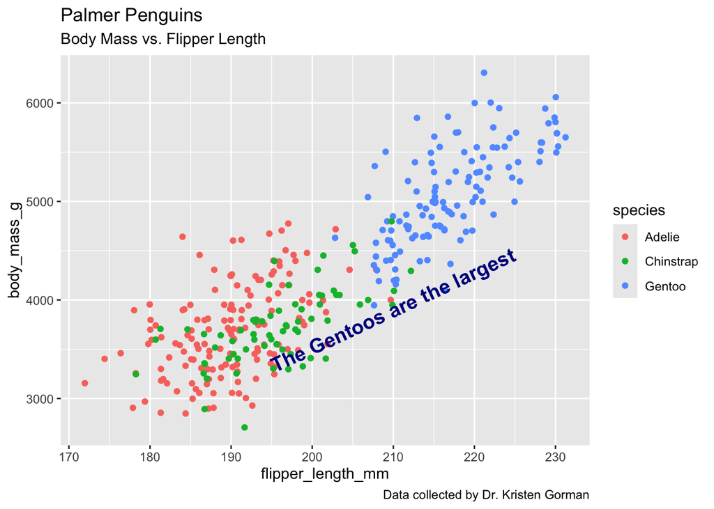

```r
ggplot(penguins) +
  geom_jitter(mapping=aes(x=flipper_length_mm,y=body_mass_g,color=species)) +
  labs(title="Palmer Penguins",subtitle="Body Mass vs. Flipper Length",caption="Data collected by Dr. Kristen Gorman") +
  annotate(geom="text", x=210, y=3900, label="The Gentoos are the largest",color="darkblue",size=5,fontface="bold",angle=25)
```

You can even store the plot as a variable, and add layers (also via `+`) on the variable afterwards.

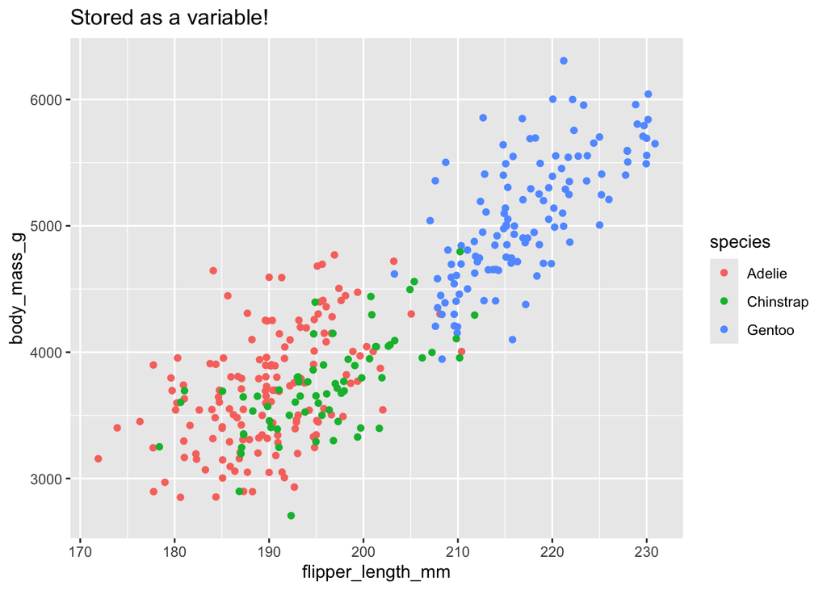

```r
p <- ggplot(penguins) +
  geom_jitter(mapping=aes(x=flipper_length_mm,y=body_mass_g,color=species))

p + labs(title="Stored as a variable!")
```

#### Saving our viz

- ‘Export’ option in Plots panel.
- `ggsave("file_name")`: defaults to **saving the last plot** that you displayed and **uses the size of the current graphics device**.

```r
ggsave("20250422test.png")
```

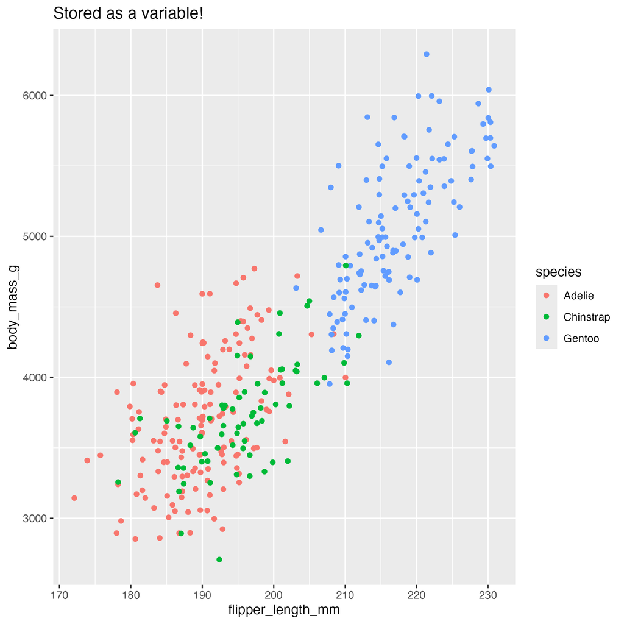

The output: 20250422test.png

Note that its size is adjusted according to the current device rather than the preview shown under each code chunk.

`˖°𖥔 ݁ ˖⋅˚₊ The end!!!! ~(=^･ω･^)ﾍ >ﾟ let's go bioinformatics whoo hooo)`